# Getting Started with Modeltime Ensemble

> Ensemble Algorithms for Time Series Forecasting with Modeltime

A `modeltime` extension that that implements *ensemble forecasting methods* including model averaging, weighted averaging, and stacking. Let’s go through a guided tour to kick the tires on `modeltime.ensemble`.

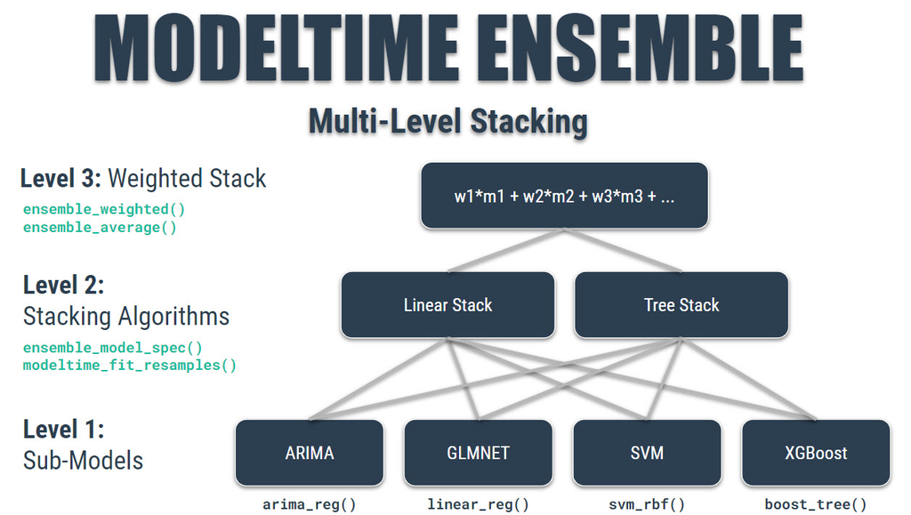

# Time Series Ensemble Forecasting Example

We’ll perform the simplest type of forecasting: **Using a simple average of the forecasted models.**

Note that `modeltime.ensemble` has capabilities for more sophisticated model ensembling using:

- **Weighted Averaging**
- **Stacking** using an Elastic Net regression model (meta-learning)

## Libraries

Load libraries to complete this short tutorial.

```r
# Time Series ML
library(tidymodels)
library(modeltime)
library(modeltime.ensemble)

# Core
library(tidyverse)
library(timetk)

interactive <- FALSE
```

## Collect the Data

We’ll use the `m750` dataset that comes with `modeltime.ensemble`. We can visualize the dataset.

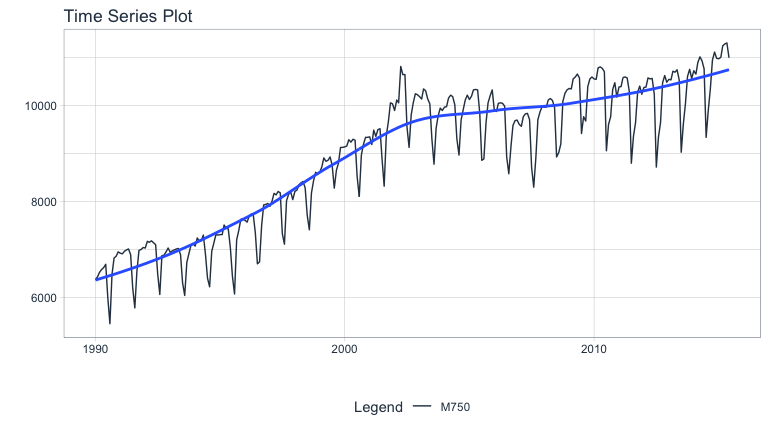

```r
m750 %>%
    plot_time_series(date, value, .color_var = id, .interactive = interactive)
```

# Perform Train / Test Splitting

We’ll split into a training and testing set.

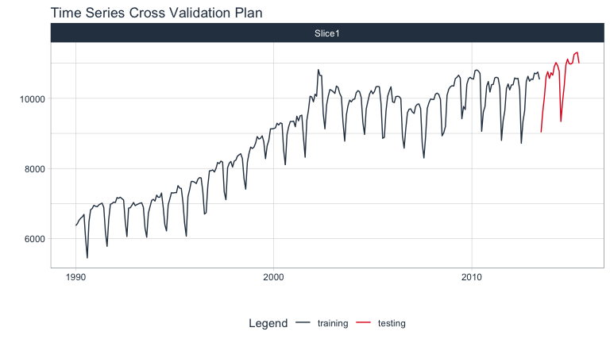

```r
splits <- time_series_split(m750, assess = "2 years", cumulative = TRUE)

splits %>%
    tk_time_series_cv_plan() %>%
    plot_time_series_cv_plan(date, value, .interactive = interactive)
```

# Modeling

Once the data has been collected, we can move into modeling.

## Recipe

We’ll create a Feature Engineering Recipe that can be applied to the data to create features that machine learning models can key in on. This will be most useful for the **Elastic Net (Model 3).**

```r
recipe_spec <- recipe(value ~ date, training(splits)) %>%
    step_timeseries_signature(date) %>%
    step_rm(matches("(.iso$)|(.xts$)")) %>%
    step_normalize(matches("(index.num$)|(_year$)")) %>%
    step_dummy(all_nominal()) %>%
    step_fourier(date, K = 1, period = 12)

recipe_spec %>% prep() %>% juice()
```

```
#> # A tibble: 282 × 42
#>    date       value date_index.num date_year date_half date_quarter date_month
#>    <date>     <dbl>          <dbl>     <dbl>     <int>        <int>      <int>
#>  1 1990-01-01  6370          -1.72     -1.66         1            1          1
#>  2 1990-02-01  6430          -1.71     -1.66         1            1          2
#>  3 1990-03-01  6520          -1.70     -1.66         1            1          3
#>  4 1990-04-01  6580          -1.69     -1.66         1            2          4
#>  5 1990-05-01  6620          -1.67     -1.66         1            2          5
#>  6 1990-06-01  6690          -1.66     -1.66         1            2          6
#>  7 1990-07-01  6000          -1.65     -1.66         2            3          7
#>  8 1990-08-01  5450          -1.64     -1.66         2            3          8
#>  9 1990-09-01  6480          -1.62     -1.66         2            3          9
#> 10 1990-10-01  6820          -1.61     -1.66         2            4         10
#> # ℹ 272 more rows
#> # ℹ 35 more variables: date_day <int>, date_hour <int>, date_minute <int>,
#> #   date_second <int>, date_hour12 <int>, date_am.pm <int>, date_wday <int>,
#> #   date_mday <int>, date_qday <int>, date_yday <int>, date_mweek <int>,
#> #   date_week <int>, date_week2 <int>, date_week3 <int>, date_week4 <int>,
#> #   date_mday7 <int>, date_month.lbl_01 <dbl>, date_month.lbl_02 <dbl>,
#> #   date_month.lbl_03 <dbl>, date_month.lbl_04 <dbl>, …
```

## Model 1 - Auto ARIMA

First, we’ll make an ARIMA model using Auto ARIMA.

```r
model_spec_arima <- arima_reg() %>%
    set_engine("auto_arima")

wflw_fit_arima <- workflow() %>%
    add_model(model_spec_arima) %>%
    add_recipe(recipe_spec %>% step_rm(all_predictors(), -date)) %>%
    fit(training(splits))
```

## Model 2 - Prophet

Next, we’ll make a Prophet Model.

```r
model_spec_prophet <- prophet_reg() %>%
    set_engine("prophet")

wflw_fit_prophet <- workflow() %>%
    add_model(model_spec_prophet) %>%
    add_recipe(recipe_spec %>% step_rm(all_predictors(), -date)) %>%
    fit(training(splits))
```

## Model 3 - Elastic Net

Third, we’ll make an Elastic Net Model using `glmnet`.

```r
model_spec_glmnet <- linear_reg(
    mixture = 0.9,
    penalty = 4.36e-6
) %>%
    set_engine("glmnet")

wflw_fit_glmnet <- workflow() %>%
    add_model(model_spec_glmnet) %>%
    add_recipe(recipe_spec %>% step_rm(date)) %>%
    fit(training(splits))
```

# Modeltime Workflow for Ensemble Forecasting

With the models created, we can can create an **Ensemble Average Model using a simple Mean Average.**

## Step 1 - Create a Modeltime Table

Create a *Modeltime Table* using the `modeltime` package.

```r
m750_models <- modeltime_table(
    wflw_fit_arima,
    wflw_fit_prophet,
    wflw_fit_glmnet
)

m750_models
```

```
#> # Modeltime Table
#> # A tibble: 3 × 3
#>   .model_id .model     .model_desc
#>       <int> <list>     <chr>
#> 1         1 <workflow> ARIMA(0,1,1)(0,1,1)[12]
#> 2         2 <workflow> PROPHET
#> 3         3 <workflow> GLMNET
```

## Step 2 - Make an Ensemble

Then use `ensemble_average()` to turn that Modeltime Table into a *Modeltime Ensemble.* This is a *fitted ensemble specification* containing the ingredients to forecast future data and be refitted on data sets using the 3 submodels.

```r
ensemble_fit <- m750_models %>%
    ensemble_average(type = "mean")

ensemble_fit
```

```
#> ── Modeltime Ensemble ───────────────────────────────────────────
#> Ensemble of 3 Models (MEAN)
#>
#> # Modeltime Table
#> # A tibble: 3 × 3
#>   .model_id .model     .model_desc
#>       <int> <list>     <chr>
#> 1         1 <workflow> ARIMA(0,1,1)(0,1,1)[12]
#> 2         2 <workflow> PROPHET
#> 3         3 <workflow> GLMNET
```

## Step 3 - Forecast! (the Test Data)

To forecast, just follow the [Modeltime Workflow](https://business-science.github.io/modeltime/articles/getting-started-with-modeltime.html).

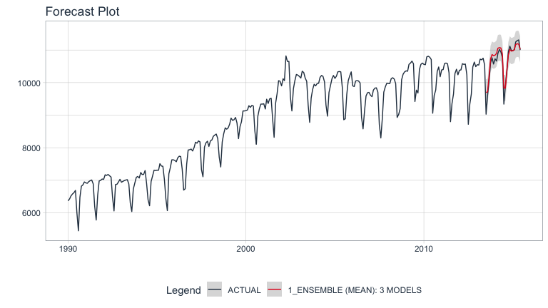

```r
# Calibration
calibration_tbl <- modeltime_table(
    ensemble_fit
) %>%
    modeltime_calibrate(testing(m750_splits))

# Forecast vs Test Set
calibration_tbl %>%
    modeltime_forecast(
        new_data    = testing(m750_splits),
        actual_data = m750
    ) %>%
    plot_modeltime_forecast(.interactive = interactive)
```

## Step 4 - Refit on Full Data & Forecast Future

Once satisfied with our ensemble model, we can `modeltime_refit()` on the full data set and forecast forward gaining the confidence intervals in the process.

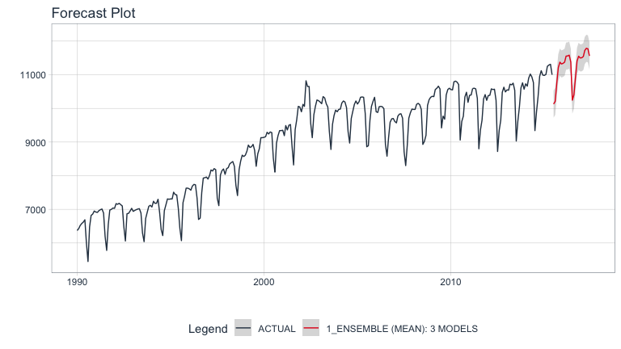

```r
refit_tbl <- calibration_tbl %>%
    modeltime_refit(m750)

refit_tbl %>%
    modeltime_forecast(
        h = "2 years",
        actual_data = m750
    ) %>%
    plot_modeltime_forecast(.interactive = interactive)
```

This was a very short tutorial on the simplest type of forecasting, but there’s a lot more to learn.

## Take the High-Performance Forecasting Course

> Become the forecasting expert for your organization

[figure not shown]

[*High-Performance Time Series Course*](https://university.business-science.io/p/ds4b-203-r-high-performance-time-series-forecasting/)

### Time Series is Changing

Time series is changing. **Businesses now need 10,000+ time series forecasts every day.** This is what I call a *High-Performance Time Series Forecasting System (HPTSF)* - Accurate, Robust, and Scalable Forecasting.

**High-Performance Forecasting Systems will save companies by improving accuracy and scalability.** Imagine what will happen to your career if you can provide your organization a “High-Performance Time Series Forecasting System” (HPTSF System).

### How to Learn High-Performance Time Series Forecasting

I teach how to build a HPTFS System in my [**High-Performance Time Series Forecasting Course**](https://university.business-science.io/p/ds4b-203-r-high-performance-time-series-forecasting). You will learn:

- **Time Series Machine Learning** (cutting-edge) with `Modeltime` - 30+ Models (Prophet, ARIMA, XGBoost, Random Forest, & many more)
- **Deep Learning** with `GluonTS` (Competition Winners)
- **Time Series Preprocessing**, Noise Reduction, & Anomaly Detection
- **Feature engineering** using lagged variables & external regressors
- **Hyperparameter Tuning**
- **Time series cross-validation**
- **Ensembling** Multiple Machine Learning & Univariate Modeling Techniques (Competition Winner)
- **Scalable Forecasting** - Forecast 1000+ time series in parallel
- and more.

Become the Time Series Expert for your organization.

[Take the High-Performance Time Series Forecasting Course](https://university.business-science.io/p/ds4b-203-r-high-performance-time-series-forecasting)